# Data Analytics-IST 707 HW03

In this report we will be analysing the Disease prediction dataset.We are going to create various disease diagnosis models using Naives Bayes Classifier, K Nearest Neighbor, Support Vector Machine, Random Forest, Gradient Boosting Classifiers in order to predict whether the patient has the specific disease.

Submitted by:Jaishree Palaniswamy

#### **Package Loading:**

Load all the required packages:

```r
library(ggplot2)
library(dplyr)
library(tidyr)
library(tidyverse)
library(caret)
library(klaR)
library(e1071)
library(mlbench)
library(kernlab)
library(randomForest)
```

####**Data Loading:**

Let us read the training and testing datasets.

```r
cardio_train<-read.csv("Disease Prediction Training.csv", header=TRUE)
cardio_test<-read.csv("Disease Prediction Testing.csv", header=TRUE)
```

#### **Data Exploration:**

```r
str(cardio_train)
```

[output not shown]

```r
summary(cardio_train)
```

[output not shown]

NA values:

```r
sapply(cardio_train, function(x) sum(is.na(x)))
```

[output not shown]

Since there are no NA’s in the dataset, we can move further with our analysis.

Removing the duplicate values from the dataset:

```r
cardio_train<-cardio_train[!duplicated(cardio_train),]
```

Handling the Outliers & Data Visualization:

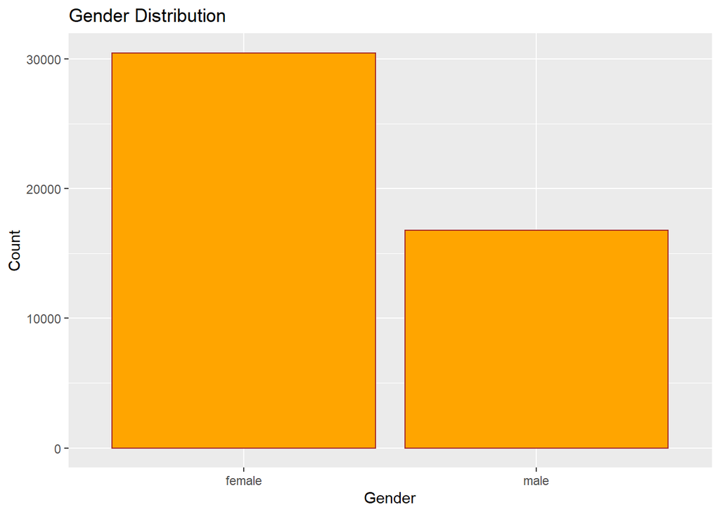

```r
ggplot(cardio_train,aes(x = Gender))+
  geom_bar(fill="orange",color="brown")+
  xlab("Gender")+
  ylab("Count")+
  ggtitle("Gender Distribution")
```

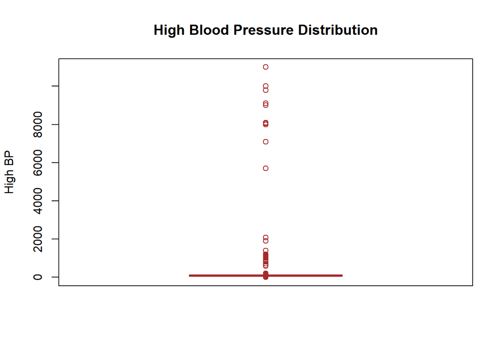

```r
boxplot(cardio_train$High.Blood.Pressure,
main = "High Blood Pressure Distribution",
ylab="High BP",
border = "brown",
vertical = TRUE
)
```

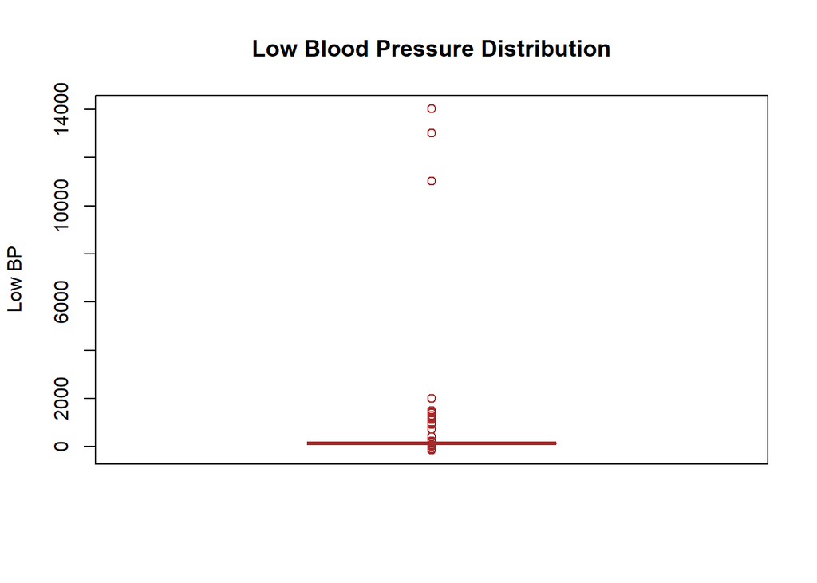

```r
boxplot(cardio_train$Low.Blood.Pressure,
main = "Low Blood Pressure Distribution",
ylab="Low BP",
border = "brown",
vertical = TRUE
)
```

From the above charts,there were many outliers in Low BP and High BP columns with values ranging from negatives to several thousands. I have removed the rows of the Low BP and High BP values that makes no sense by limiting it to particular range.I have taken the Low BP range from 20-190 and High BP range from 60-240.

```r
cardio_train <- cardio_train[cardio_train$Low.Blood.Pressure >= 20,]
cardio_train <- cardio_train[cardio_train$Low.Blood.Pressure <= 190,]

cardio_train <- cardio_train[cardio_train$High.Blood.Pressure>= 60,]
cardio_train <- cardio_train[cardio_train$High.Blood.Pressure <= 240,]
```

Then, when we look at the minimum age of the person in the dataset it is 29 but then the minimum weight in the data set is found to be 10. So, it is practically not possible to have 29year old person to weigh 10kg. So, I have taken an average range of height and weight to proceed with the analysis to have better model.

```r
cardio_train <-  cardio_train[cardio_train$Height >= 100,]
cardio_train <-  cardio_train[cardio_train$Weight >= 20,]
```

Converting the values to numeric data type:

```r
cardio_train$Age<-as.numeric(cardio_train$Age)
cardio_train$Gender<-as.numeric(cardio_train$Gender)
cardio_train$Height<-as.numeric(cardio_train$Height)
cardio_train$Weight<-as.numeric(cardio_train$Weight)
cardio_train$Low.Blood.Pressure<-as.numeric(cardio_train$Low.Blood.Pressure)
cardio_train$High.Blood.Pressure<-as.numeric(cardio_train$High.Blood.Pressure)
cardio_train$Smoke<-as.numeric(cardio_train$Smoke)
cardio_train$Cholesterol<-as.numeric(cardio_train$Cholesterol)
cardio_train$Glucose<-as.numeric(cardio_train$Glucose)
cardio_train$Alcohol<-as.numeric(cardio_train$Alcohol)
cardio_train$Exercise<-as.numeric(cardio_train$Exercise)
cardio_train$Disease <- as.factor(cardio_train$Disease)
```

#### **Training and Testing Dataset:**

Let us now split this data into train & test:

```r
train_index <- createDataPartition(cardio_train$Disease, p = 0.8, list = FALSE)
data_train <- cardio_train[train_index, ]
data_test <- cardio_train[-train_index, ]
```

#### **Naive Bayes Classifier**

Naive Bayes is a supervised machine learning algorithm used for classification of the dataset. This algorithm is based on Bayes theorem that describes the probability of event based on its prior knowledge.

Default Model:

```r
start1 <- Sys.time()
default_model <- train(Disease ~ ., data = data_train, method = "nb")
Sys.time() - start1
```

```
## Time difference of 6.444639 mins
```

```r
pred <- predict(default_model, data_test)
```

```r
confusionMatrix(pred, data_test$Disease)
```

```
## Confusion Matrix and Statistics
##
##           Reference
## Prediction    0    1
##          0 3582 1651
##          1  996 3007
##
##                Accuracy : 0.7134
##                  95% CI : (0.7041, 0.7226)
##     No Information Rate : 0.5043
##     P-Value [Acc > NIR] : < 2.2e-16
##
##                   Kappa : 0.4275
##
##  Mcnemar's Test P-Value : < 2.2e-16
##
##             Sensitivity : 0.7824
##             Specificity : 0.6456
##          Pos Pred Value : 0.6845
##          Neg Pred Value : 0.7512
##              Prevalence : 0.4957
##          Detection Rate : 0.3878
##    Detection Prevalence : 0.5666
##       Balanced Accuracy : 0.7140
##
##        'Positive' Class : 0
##
```

#### **Tuned Model**

Now, let us fine tune the model with additional parameters.

```r
start3 <- Sys.time()

tuned_nb <- train(Disease ~ ., data = data_train, method = "nb",
                  trControl = trainControl(method = "cv", number=3),
                  tuneGrid = expand.grid(fL = 1:3, usekernel = T, adjust = 1:3))

Sys.time() - start3
```

```
## Time difference of 4.860614 mins
```

Predicting the Disease on test dataset:

```r
predict_tuned_nb<- predict(tuned_nb, newdata = data_test, type = "raw")
```

Calculating the accuracy of the model:

```r
confusionMatrix(predict_tuned_nb, data_test$Disease)
```

```
## Confusion Matrix and Statistics
##
##           Reference
## Prediction    0    1
##          0 3869 1983
##          1  709 2675
##
##                Accuracy : 0.7085
##                  95% CI : (0.6991, 0.7178)
##     No Information Rate : 0.5043
##     P-Value [Acc > NIR] : < 2.2e-16
##
##                   Kappa : 0.4184
##
##  Mcnemar's Test P-Value : < 2.2e-16
##
##             Sensitivity : 0.8451
##             Specificity : 0.5743
##          Pos Pred Value : 0.6611
##          Neg Pred Value : 0.7905
##              Prevalence : 0.4957
##          Detection Rate : 0.4189
##    Detection Prevalence : 0.6336
##       Balanced Accuracy : 0.7097
##
##        'Positive' Class : 0
##
```

#### **K-Nearest Neighbours**

K-Nearest Neighbours is one of the most basic yet essential classification algorithms in Machine Learning. It belongs to the supervised learning domain and finds intense application in pattern recognition, data mining and intrusion detection.

It is widely disposable in real-life scenarios since it is non-parametric, meaning, it does not make any underlying assumptions about the distribution of data (as opposed to other algorithms such as GMM, which assume a Gaussian distribution of the given data).

Default Model:

```r
model_knn1 <- train(Disease ~ ., data = data_train, method = "knn")
```

```r
predict_knn1 <- predict(model_knn1, newdata = data_test)
```

```r
confusionMatrix(predict_knn1, data_test$Disease)
```

```
## Confusion Matrix and Statistics
##
##           Reference
## Prediction    0    1
##          0 3294 1486
##          1 1284 3172
##
##                Accuracy : 0.7001
##                  95% CI : (0.6906, 0.7094)
##     No Information Rate : 0.5043
##     P-Value [Acc > NIR] : < 2.2e-16
##
##                   Kappa : 0.4004
##
##  Mcnemar's Test P-Value : 0.000134
##
##             Sensitivity : 0.7195
##             Specificity : 0.6810
##          Pos Pred Value : 0.6891
##          Neg Pred Value : 0.7118
##              Prevalence : 0.4957
##          Detection Rate : 0.3566
##    Detection Prevalence : 0.5175
##       Balanced Accuracy : 0.7003
##
##        'Positive' Class : 0
##
```

Model Training:

```r
start1 <- Sys.time()
model_knn2 <- train(Disease ~ ., data = data_train, method = "knn",
                    tuneGrid = data.frame(k = seq(1, 25)),
                    trControl = trainControl(method = "repeatedcv",
                                             number = 3, repeats = 3))
Sys.time() - start1
```

```
## Time difference of 12.22146 mins
```

Predicting the disease on the testing data set:

```r
predict_knn2 <- predict(model_knn2, newdata = data_test, type = "raw")
```

Confusion Matrix for checking accuracy:

```r
confusionMatrix(predict_knn2, data_test$Disease)
```

```
## Confusion Matrix and Statistics
##
##           Reference
## Prediction    0    1
##          0 3397 1451
##          1 1181 3207
##
##                Accuracy : 0.715
##                  95% CI : (0.7057, 0.7242)
##     No Information Rate : 0.5043
##     P-Value [Acc > NIR] : < 2.2e-16
##
##                   Kappa : 0.4303
##
##  Mcnemar's Test P-Value : 1.577e-07
##
##             Sensitivity : 0.7420
##             Specificity : 0.6885
##          Pos Pred Value : 0.7007
##          Neg Pred Value : 0.7309
##              Prevalence : 0.4957
##          Detection Rate : 0.3678
##    Detection Prevalence : 0.5249
##       Balanced Accuracy : 0.7153
##
##        'Positive' Class : 0
##
```

#### **Support Vector Machine**

A Support Vector Machine (SVM) is a supervised machine learning algorithm that can be employed for both classification and regression purposes. SVMs are more commonly used in classification problems. So, lets go ahead and train the model on the trianing data:

Linear Model:

```r
start1 <- Sys.time()
model_svm_linear <- train(Disease ~ ., data = data_train,
                          method = "svmLinear",
                          preProcess = c("center", "scale"),
                          trControl = trainControl(method = "cv", number = 3),
                          tuneGrid = expand.grid(C = seq(0, 1, 0.05)))
Sys.time()-start1
```

```
## Time difference of 21.09027 mins
```

Lets have a look at the model:

```r
model_svm_linear
```

```
## Support Vector Machines with Linear Kernel
##
## 36947 samples
##    11 predictor
##     2 classes: '0', '1'
##
## Pre-processing: centered (11), scaled (11)
## Resampling: Cross-Validated (3 fold)
## Summary of sample sizes: 24631, 24632, 24631
## Resampling results across tuning parameters:
##
##   C     Accuracy   Kappa
##   0.00        NaN        NaN
##   0.05  0.7223863  0.4454742
##   0.10  0.7224134  0.4455296
##   0.15  0.7223322  0.4453677
##   0.20  0.7223051  0.4453155
##   0.25  0.7223322  0.4453687
##   0.30  0.7223592  0.4454236
##   0.35  0.7223592  0.4454225
##   0.40  0.7223322  0.4453687
##   0.45  0.7223592  0.4454225
##   0.50  0.7224404  0.4455855
##   0.55  0.7223322  0.4453682
##   0.60  0.7224134  0.4455312
##   0.65  0.7223322  0.4453698
##   0.70  0.7224134  0.4455301
##   0.75  0.7223592  0.4454236
##   0.80  0.7223051  0.4453144
##   0.85  0.7223863  0.4454768
##   0.90  0.7223863  0.4454769
##   0.95  0.7223592  0.4454225
##   1.00  0.7223051  0.4453155
##
## Accuracy was used to select the optimal model using the largest value.
## The final value used for the model was C = 0.5.
```

Lets predict the disease on test data set

```r
predict_svm_linear <- predict(model_svm_linear, newdata = data_test)
```

Checking the accuracy of the model

```r
confusionMatrix(predict_svm_linear, data_test$Disease)
```

```
## Confusion Matrix and Statistics
##
##           Reference
## Prediction    0    1
##          0 3607 1615
##          1  971 3043
##
##                Accuracy : 0.72
##                  95% CI : (0.7107, 0.7291)
##     No Information Rate : 0.5043
##     P-Value [Acc > NIR] : < 2.2e-16
##
##                   Kappa : 0.4407
##
##  Mcnemar's Test P-Value : < 2.2e-16
##
##             Sensitivity : 0.7879
##             Specificity : 0.6533
##          Pos Pred Value : 0.6907
##          Neg Pred Value : 0.7581
##              Prevalence : 0.4957
##          Detection Rate : 0.3905
##    Detection Prevalence : 0.5654
##       Balanced Accuracy : 0.7206
##
##        'Positive' Class : 0
##
```

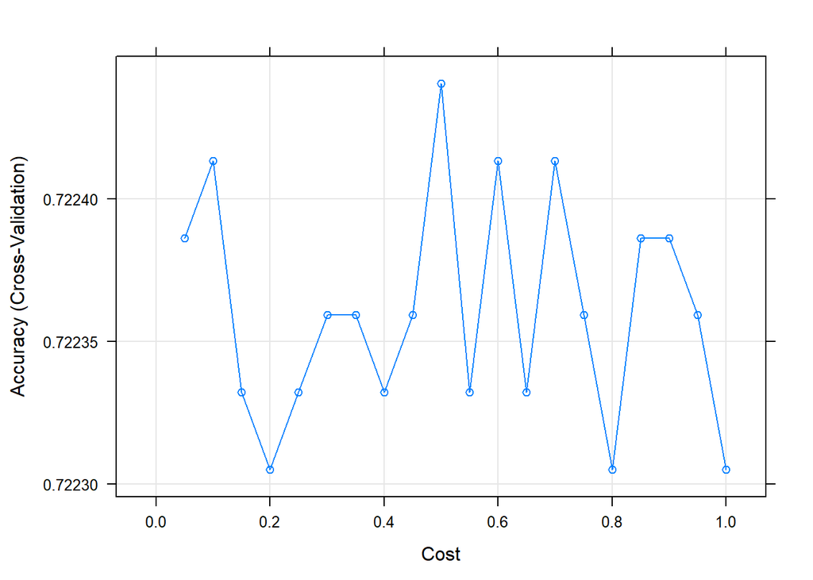

```r
plot(model_svm_linear)
```

NON LINEAR MODEL:

```r
model_svm_rbf <- ksvm(Disease ~ ., data = data_train,
                       preProcess = c("center", "scale"),
                       tuneGrid = expand.grid(sigma = seq(0, 1, 0.1),
                                              C = seq(0, 1, 0.1)),
                       method = "svmRadial",
                       trControl = trainControl(method = "cv",
                                                number = 3))
```

Lets predict the disease on test data set

```r
predict_svm_rbf <- predict(model_svm_rbf, newdata = data_test)
```

Checking the accuracy of the model

```r
confusionMatrix(predict_svm_rbf, data_test$Disease)
```

```
## Confusion Matrix and Statistics
##
##           Reference
## Prediction    0    1
##          0 3532 1465
##          1 1046 3193
##
##                Accuracy : 0.7281
##                  95% CI : (0.7189, 0.7372)
##     No Information Rate : 0.5043
##     P-Value [Acc > NIR] : < 2.2e-16
##
##                   Kappa : 0.4566
##
##  Mcnemar's Test P-Value : < 2.2e-16
##
##             Sensitivity : 0.7715
##             Specificity : 0.6855
##          Pos Pred Value : 0.7068
##          Neg Pred Value : 0.7532
##              Prevalence : 0.4957
##          Detection Rate : 0.3824
##    Detection Prevalence : 0.5410
##       Balanced Accuracy : 0.7285
##
##        'Positive' Class : 0
##
```

#### **Random Forest**

Random Forest algorithm can be used for both regression and classification problems. Two methods for tuning the model for, 1. Random Search and 2. Grid Search

Grid Search: In grid search the model is evaluated with all the combinations that are passed in the function, using cross-validation

Random Search: Unlike grid search, random search will not evaluate all the combinations of hyperparameters, instead a random combination is chosen at every iteration.

For tuning, let us use grid search.

Default setting:

```r
trControl <- trainControl(method = "cv",
                          number = 3,
                          search = "grid")
```

```r
set.seed(1234)
default_rf_model <- train(Disease~.,
                          data = data_train,
                          method = "rf",
                          metric = "Accuracy",
                          trControl = trControl)
```

Let us test the values of mtry from 1 to 10

```r
set.seed(1234)
tuneGrid <- expand.grid(.mtry = c(1:10))
rf_mtry <- train(Disease~.,
                 data = data_train,
                 method = "rf",
                 metric = "Accuracy",
                 tuneGrid = tuneGrid,
                 trControl = trControl,
                 importance = TRUE,
                 nodesize = 25,
                 ntree = 350)
```

mtry (between values of 1 and 10) with the best accuracy is chosen.

Let us store the best value of mtry in best_mtry

```r
best_mtry <- rf_mtry$bestTune$mtry
```

The next step is to search for the best maxnodes.

```r
store_maxnode <- list()
tuneGrid <- expand.grid(.mtry = best_mtry)
for (maxnodes in c(20: 30)) {
  set.seed(1234)
  rf_maxnode <- train(Disease~.,
                      data = data_train,
                      method = "rf",
                      metric = "Accuracy",
                      tuneGrid = tuneGrid,
                      trControl = trControl,
                      importance = TRUE,
                      nodesize = 25,
                      maxnodes = maxnodes,
                      ntree = 350)
  key <- toString(maxnodes)
  store_maxnode[[key]] <- rf_maxnode
}
results_node <- resamples(store_maxnode)
summary(results_node)
```

```
##
## Call:
## summary.resamples(object = results_node)
##
## Models: 20, 21, 22, 23, 24, 25, 26, 27, 28, 29, 30
## Number of resamples: 3
##
## Accuracy
##         Min.   1st Qu.    Median      Mean   3rd Qu.      Max. NA's
## 20 0.7219065 0.7223012 0.7226959 0.7260128 0.7280660 0.7334362    0
## 21 0.7219877 0.7221388 0.7222899 0.7257422 0.7276194 0.7329490    0
## 22 0.7216403 0.7219764 0.7223124 0.7264729 0.7288892 0.7354661    0
## 23 0.7218027 0.7222199 0.7226372 0.7258504 0.7278743 0.7331114    0
## 24 0.7227184 0.7229508 0.7231831 0.7263376 0.7281473 0.7331114    0
## 25 0.7235304 0.7235597 0.7235891 0.7266083 0.7281473 0.7327054    0
## 26 0.7222087 0.7225041 0.7227996 0.7266624 0.7288892 0.7349789    0
## 27 0.7231831 0.7233161 0.7234492 0.7270143 0.7289298 0.7344105    0
## 28 0.7221275 0.7227071 0.7232868 0.7269060 0.7292952 0.7353037    0
## 29 0.7227184 0.7228290 0.7229395 0.7268519 0.7289186 0.7348977    0
## 30 0.7218253 0.7220576 0.7222899 0.7260670 0.7281878 0.7340857    0
##
## Kappa
##         Min.   1st Qu.    Median      Mean   3rd Qu.      Max. NA's
## 20 0.4442411 0.4450711 0.4459012 0.4524806 0.4566003 0.4672994    0
## 21 0.4444057 0.4447146 0.4450234 0.4519158 0.4556708 0.4663183    0
## 22 0.4437864 0.4444245 0.4450627 0.4534285 0.4582495 0.4714364    0
## 23 0.4440592 0.4448744 0.4456896 0.4521214 0.4561526 0.4666155    0
## 24 0.4458401 0.4463512 0.4468622 0.4531277 0.4567715 0.4666808    0
## 25 0.4475210 0.4475976 0.4476743 0.4536829 0.4567639 0.4658535    0
## 26 0.4449574 0.4455055 0.4460536 0.4537990 0.4582199 0.4703862    0
## 27 0.4468965 0.4471272 0.4473579 0.4544978 0.4582985 0.4692390    0
## 28 0.4447693 0.4458888 0.4470082 0.4542639 0.4590112 0.4710141    0
## 29 0.4458890 0.4461193 0.4463497 0.4541544 0.4582872 0.4702246    0
## 30 0.4441049 0.4446002 0.4450954 0.4525877 0.4568291 0.4685627    0
```

Now, let us tune the number of trees.

```r
store_maxtrees <- list()
for (ntree in c(250, 300, 350, 400, 450, 500, 550, 600, 800, 1000, 2000)) {
  set.seed(5678)
  rf_maxtrees <- train(Disease~.,
                       data = data_train,
                       method = "rf",
                       metric = "Accuracy",
                       tuneGrid = tuneGrid,
                       trControl = trControl,
                       importance = TRUE,
                       nodesize = 25,
                       maxnodes = 24,
                       ntree = ntree)
  key <- toString(ntree)
  store_maxtrees[[key]] <- rf_maxtrees
}
results_tree <- resamples(store_maxtrees)
summary(results_tree)
```

```
##
## Call:
## summary.resamples(object = results_tree)
##
## Models: 250, 300, 350, 400, 450, 500, 550, 600, 800, 1000, 2000
## Number of resamples: 3
##
## Accuracy
##           Min.   1st Qu.    Median      Mean   3rd Qu.      Max. NA's
## 250  0.7229395 0.7240063 0.7250731 0.7264188 0.7281585 0.7312439    0
## 300  0.7222899 0.7236003 0.7249107 0.7259046 0.7277119 0.7305132    0
## 350  0.7228583 0.7239251 0.7249919 0.7261211 0.7277525 0.7305132    0
## 400  0.7221275 0.7235597 0.7249919 0.7262564 0.7283209 0.7316499    0
## 450  0.7226959 0.7237221 0.7247483 0.7260940 0.7277931 0.7308379    0
## 500  0.7226959 0.7238033 0.7249107 0.7262023 0.7279555 0.7310003    0
## 550  0.7222899 0.7236815 0.7250731 0.7260940 0.7279961 0.7309191    0
## 600  0.7223711 0.7237221 0.7250731 0.7258504 0.7275901 0.7301072    0
## 800  0.7226147 0.7237221 0.7248295 0.7256881 0.7272247 0.7296200    0
## 1000 0.7222087 0.7233973 0.7245859 0.7256069 0.7273059 0.7300260    0
## 2000 0.7226959 0.7236003 0.7245047 0.7260670 0.7277525 0.7310003    0
##
## Kappa
##           Min.   1st Qu.    Median      Mean   3rd Qu.      Max. NA's
## 250  0.4463372 0.4484303 0.4505233 0.4532813 0.4567533 0.4629834    0
## 300  0.4450328 0.4476228 0.4502128 0.4522673 0.4558845 0.4615561    0
## 350  0.4461710 0.4482703 0.4503696 0.4526959 0.4559583 0.4615469    0
## 400  0.4447130 0.4475358 0.4503587 0.4529694 0.4570976 0.4638365    0
## 450  0.4458512 0.4478642 0.4498773 0.4526593 0.4560634 0.4622494    0
## 500  0.4458434 0.4480258 0.4502081 0.4528695 0.4563826 0.4625570    0
## 550  0.4450312 0.4477804 0.4505296 0.4526521 0.4564626 0.4623956    0
## 600  0.4451974 0.4478619 0.4505264 0.4521688 0.4556545 0.4607826    0
## 800  0.4456866 0.4478690 0.4500513 0.4518552 0.4549395 0.4598277    0
## 1000 0.4448776 0.4472191 0.4495606 0.4516967 0.4551062 0.4606518    0
## 2000 0.4458387 0.4476165 0.4493944 0.4526008 0.4559818 0.4625693    0
```

Let us train the random forest model with the parameters.

```r
fit_rf <- train(Disease~.,
                data_train,
                method = "rf",
                metric = "Accuracy",
                tuneGrid = tuneGrid,
                trControl = trControl,
                importance = TRUE,
                nodesize = 25,
                ntree = 350,
                maxnodes = 30)
```

Let us predict the disease on test data set

```r
prediction <-predict(fit_rf, data_test)
```

Checking for the accuracy

```r
confusionMatrix(prediction, data_test$Disease)
```

```
## Confusion Matrix and Statistics
##
##           Reference
## Prediction    0    1
##          0 3498 1473
##          1 1080 3185
##
##                Accuracy : 0.7236
##                  95% CI : (0.7143, 0.7327)
##     No Information Rate : 0.5043
##     P-Value [Acc > NIR] : < 2.2e-16
##
##                   Kappa : 0.4475
##
##  Mcnemar's Test P-Value : 8.615e-15
##
##             Sensitivity : 0.7641
##             Specificity : 0.6838
##          Pos Pred Value : 0.7037
##          Neg Pred Value : 0.7468
##              Prevalence : 0.4957
##          Detection Rate : 0.3787
##    Detection Prevalence : 0.5382
##       Balanced Accuracy : 0.7239
##
##        'Positive' Class : 0
##
```

Now, lets check for the variables that contributes more for the model.

```r
varimp_rf <- varImp(fit_rf)
varimp_rf
```

```
## rf variable importance
##
##                     Importance
## Low.Blood.Pressure     100.000
## Cholesterol             73.410
## Age                     50.583
## High.Blood.Pressure     39.688
## Weight                  19.822
## Exercise                17.950
## Glucose                 13.457
## Smoke                    4.657
## Height                   4.348
## Gender                   1.875
## Alcohol                  0.000
```

#### **Gradient Boosting Machine**

GBM is a machine learning technique for regression and classification problems. It builds the model in a stage-wise fashion like other boosting methods do, and it generalizes them by allowing optimization of an arbitrary differentiable loss function.

```r
model_gbm <- train(Disease ~ ., data = data_train, method = "gbm")
```

Let us predict the disease on test data set

```r
prediction_gbm <-predict(model_gbm, data_test)
```

Let us check the accuracy of the model

```r
confusionMatrix(prediction_gbm, data_test$Disease)
```

```
## Confusion Matrix and Statistics
##
##           Reference
## Prediction    0    1
##          0 3450 1333
##          1 1128 3325
##
##                Accuracy : 0.7335
##                  95% CI : (0.7244, 0.7425)
##     No Information Rate : 0.5043
##     P-Value [Acc > NIR] : < 2.2e-16
##
##                   Kappa : 0.4673
##
##  Mcnemar's Test P-Value : 3.919e-05
##
##             Sensitivity : 0.7536
##             Specificity : 0.7138
##          Pos Pred Value : 0.7213
##          Neg Pred Value : 0.7467
##              Prevalence : 0.4957
##          Detection Rate : 0.3735
##    Detection Prevalence : 0.5179
##       Balanced Accuracy : 0.7337
##
##        'Positive' Class : 0
##
```

Model Training:

```r
set.seed(825)
gbmFit1 <- train(Disease ~ ., data = data_train,
                 method = "gbm",
                 trControl = trainControl(method = "cv", number = 3),
                 verbose = FALSE)
gbmFit1
```

```
## Stochastic Gradient Boosting
##
## 36947 samples
##    11 predictor
##     2 classes: '0', '1'
##
## No pre-processing
## Resampling: Cross-Validated (3 fold)
## Summary of sample sizes: 24631, 24632, 24631
## Resampling results across tuning parameters:
##
##   interaction.depth  n.trees  Accuracy   Kappa
##   1                   50      0.7205999  0.4419220
##   1                  100      0.7248492  0.4503704
##   1                  150      0.7279888  0.4565654
##   2                   50      0.7271498  0.4547728
##   2                  100      0.7327795  0.4659203
##   2                  150      0.7334291  0.4671868
##   3                   50      0.7305601  0.4614275
##   3                  100      0.7338080  0.4678823
##   3                  150      0.7340516  0.4683518
##
## Tuning parameter 'shrinkage' was held constant at a value of 0.1
##
## Tuning parameter 'n.minobsinnode' was held constant at a value of 10
## Accuracy was used to select the optimal model using the largest value.
## The final values used for the model were n.trees = 150, interaction.depth =
##  3, shrinkage = 0.1 and n.minobsinnode = 10.
```

Lets predict the disease

```r
prediction_gbm_tuned <-predict(gbmFit1, data_test)
```

Check for accuracy

```r
confusionMatrix(prediction_gbm_tuned, data_test$Disease)
```

```
## Confusion Matrix and Statistics
##
##           Reference
## Prediction    0    1
##          0 3436 1319
##          1 1142 3339
##
##                Accuracy : 0.7335
##                  95% CI : (0.7244, 0.7425)
##     No Information Rate : 0.5043
##     P-Value [Acc > NIR] : < 2.2e-16
##
##                   Kappa : 0.4672
##
##  Mcnemar's Test P-Value : 0.0003885
##
##             Sensitivity : 0.7505
##             Specificity : 0.7168
##          Pos Pred Value : 0.7226
##          Neg Pred Value : 0.7451
##              Prevalence : 0.4957
##          Detection Rate : 0.3720
##    Detection Prevalence : 0.5148
##       Balanced Accuracy : 0.7337
##
##        'Positive' Class : 0
##
```

Lets compare the model outputs

```r
model_comparison <- resamples(list(NB=tuned_nb,svm=model_svm_linear, rf=fit_rf, gbm=gbmFit1))
summary(model_comparison)
```

```
##
## Call:
## summary.resamples(object = model_comparison)
##
## Models: NB, svm, rf, gbm
## Number of resamples: 3
##
## Accuracy
##          Min.   1st Qu.    Median      Mean   3rd Qu.      Max. NA's
## NB  0.7071052 0.7081320 0.7091588 0.7107748 0.7126096 0.7160604    0
## svm 0.7190646 0.7193488 0.7196330 0.7224404 0.7241283 0.7286236    0
## rf  0.7244823 0.7255491 0.7266158 0.7267166 0.7278337 0.7290516    0
## gbm 0.7317311 0.7325024 0.7332738 0.7340516 0.7352118 0.7371498    0
##
## Kappa
##          Min.   1st Qu.    Median      Mean   3rd Qu.      Max. NA's
## NB  0.4156134 0.4176506 0.4196878 0.4229072 0.4265542 0.4334206    0
## svm 0.4388548 0.4393950 0.4399351 0.4455855 0.4489509 0.4579666    0
## rf  0.4493730 0.4515640 0.4537551 0.4539152 0.4561863 0.4586175    0
## gbm 0.4636821 0.4652572 0.4668323 0.4683518 0.4706866 0.4745410    0
```

##### **Testing Data Exploration**

```r
sapply(cardio_test, function(x) sum(is.na(x)))
cardio_test<-cardio_test[!duplicated(cardio_test),]
cardio_test<- cardio_test[cardio_test$Low.Blood.Pressure >= 20,]
cardio_test <-  cardio_test[cardio_test$Low.Blood.Pressure <= 190,]
cardio_test <-  cardio_test[cardio_test$High.Blood.Pressure>= 60,]
cardio_test <-  cardio_test[cardio_test$High.Blood.Pressure <= 240,]
cardio_test <-  cardio_test[cardio_test$Height >= 100,]
cardio_test <-  cardio_test[cardio_test$Weight >= 20,]
```

```r
cardio_test$Weight<-as.numeric(cardio_test$Weight)
cardio_test$Age<-as.numeric(cardio_test$Age)
cardio_test$Gender<-as.numeric(cardio_test$Gender)
cardio_test$Cholesterol<-as.numeric(cardio_test$Cholesterol)
cardio_test$Glucose<-as.numeric(cardio_test$Glucose)
cardio_test$Height<-as.numeric(cardio_test$Height)
cardio_test$Low.Blood.Pressure<-as.numeric(cardio_test$Low.Blood.Pressure)
cardio_test$High.Blood.Pressure<-as.numeric(cardio_test$High.Blood.Pressure)
cardio_test$Smoke<-as.numeric(cardio_test$Smoke)
cardio_test$Alcohol<-as.numeric(cardio_test$Alcohol)
cardio_test$Exercise<-as.numeric(cardio_test$Exercise)
cardio_test <- cardio_test [-c(1)]
```

Finally, once the testing data set is ready, lets run the models on the testing data set for predicting the disease.

```r
NB <- predict(tuned_nb, newdata = cardio_test)
KNN<-predict(model_knn2, newdata = cardio_test)
SVM_linear<-predict(model_svm_linear, newdata = cardio_test)
SVM_nonlinear<-predict(model_svm_rbf, newdata = cardio_test)
RF<-predict(fit_rf, newdata = cardio_test)
GBM<-predict(gbmFit1, newdata = cardio_test)
```

Now lets create a data frame in which we can store the prediction of the each model and also include an ID column.

```r
finaldisp<- data.frame(NB=NB,KNN=KNN,SVM_Linear=SVM_linear,
                          SVM_NonLinear=SVM_nonlinear,RF=RF,GBM=GBM)
finaldisp["ID"]<-seq.int(nrow(finaldisp))
```

```r
write.csv(finaldisp, file="D:/Syracuse/Semester 2/Data Analytics/HW03/finaldisp.csv",
          row.names=FALSE)
```